# FinalExam-2802461776-Ivan William Lianata

Ivan William Lianata

2025-06-20

**Video Explanation:** https://youtu.be/otPNh2EFumU?si=lvPLAaDkG7ILPGka

# Final Exam Report

## 1. Data Quality And Preprocessing

In this section, we will carry out three key steps to prepare our dataset for analysis: identifying data quality issues, cleaning the data based on our findings, and performing an initial summary to understand the key patterns. These steps correspond to parts (a), (b), and (c) of the task.

### 1a. Identifying Data Quality Issues

First, we will load the dataset, and explore to uncover, duplicate, missing value, irrelevant, inconsistent, outliers in the data.

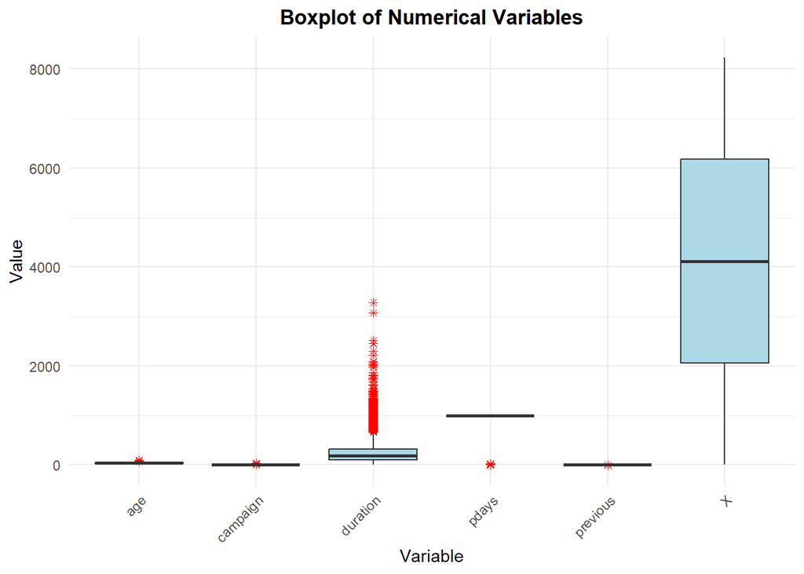

```
## === Missing Values per Column ===
##           X         age         job     marital   education     default
##           0           0           0           0           0           0
##     housing        loan     contact       month day_of_week    duration
##           0           0           0           0           0          15
##    campaign       pdays    previous    poutcome           y
##           0           0           0           0           0
##
## === Total Number of Duplicate Rows (without X) ===
## [1] 1
##
## Unique Values for 'job':
##
##                      admin.   blue-collar  entrepreneur     housemaid
##            10          2046          1860           279           188
##    management       retired self-employed      services       student
##           625           339           293           777           181
##    technician    unemployed       unknown
##          1375           201            63
##
## Unique Values for 'marital':
##
## divorced  married   single  unknown
##      936     4943     2345       13
##
## Unique Values for 'education':
##
##            basic.4y            basic.6y            basic.9y         high.school
##                 862                 456                1157                1902
##          illiterate professional.course   university.degree             unknown
##                   6                1070                2456                 328
##
## Unique Values for 'default':
##
##      no unknown     yes
##    6533    1701       3
##
## Unique Values for 'housing':
##
##      no unknown     yes
```

[output cut: 60 more lines]

```
##  cellular :5253   may    :2754   fri:1607    Min.   :   0.0   Min.   : 1.000
##  telephone:2984   jul    :1439   mon:1703    1st Qu.: 103.0   1st Qu.: 1.000
##                   aug    :1200   thu:1636    Median : 183.0   Median : 2.000
##                   jun    :1051   tue:1623    Mean   : 260.2   Mean   : 2.555
##                   nov    : 857   wed:1668    3rd Qu.: 324.0   3rd Qu.: 3.000
##                   apr    : 519               Max.   :3284.0   Max.   :43.000
##                   (Other): 417               NA's   :15
##      pdays          previous             poutcome      y
##  Min.   :  0.0   Min.   :0.0000   failure    : 876   no :7303
##  1st Qu.:999.0   1st Qu.:0.0000   nonexistent:7087   yes: 934
##  Median :999.0   Median :0.0000   success    : 274
##  Mean   :962.4   Mean   :0.1724
##  3rd Qu.:999.0   3rd Qu.:0.0000
##  Max.   :999.0   Max.   :6.0000
##
```

**Summary of Findings:**  
Based on the output from the code chunk above, we can identify the following issues:

1. **Missing Values:**  
   There are missing values in the duration and job columns. In job, some entries are empty (““). Several other columns also have”unknown” values, which means the data is incomplete, including: marital, education, default, housing, and loan.
2. **Duplicate Records:** The data contains 1 duplicated row.
3. **Outliers or Extreme Values:**  
   Some numeric columns have very high values:
- `"duration"`: has a maximum of 3284, while the median is only 183 → this is an extreme outlier.
- `"campaign"`: maximum value is 43, which seems unrealistic.
- `"pdays"`: many values are 999, which is used as a placeholder.
- `"previous"`: is skewed but the values are still reasonable, so it’s not a big issue.
4. **Inconsistent Categories:**  
   In the job column, one of the values is written as “admin.” (with a dot), while the rest don’t have a dot. This makes the category inconsistent.
5. **Irrelevant Values:**  
   The value 999 in the pdays column does not represent a real number. It is used to mark clients who were never contacted before, so it’s considered irrelevant in its current form.

### 1b. Handling Data Issues

**Cleaning Decisions:**

1. **Remove Duplicated Rows:**  
   All duplicated rows were removed to avoid double counting and ensure each observation is unique.
2. **Handle Outliers:**  
   Extreme values were capped using the boxplot rule (3 × IQR).  
   This method was chosen because several numeric variables had high skewness (skewness values between 3–4).
3. **Handle Missing Values:**
   - For numeric variables, missing values were imputed using the **median**, which is more robust for skewed distributions.
   - For `job`, missing values were replaced with `"other"`.
4. **Recode Inconsistent Job Categories:** Similar job titles were grouped into broader categories to reduce fragmentation and improve interpretability:
   - `"admin."`, `"management"`, `"technician"` → **white-collar**
   - `"blue-collar"`, `"services"`, `"housemaid"` → **blue-collar**
   - `"entrepreneur"`, `"self-employed"` → **self-employed**
   - `"student"` → **student**
   - `"retired"`, `"unemployed"` → **non-working**

   Logical adjustments were also applied:
   - If `job == "other"` and `age > 60`, then recoded as **non-working**
   - If education level is **high**, recoded as **white-collar**
   - If education level is **low**, recoded as **blue-collar**
5. **Handle “unknown” Values in Categorical Columns:**
   - `education == "unknown"`: grouped by `job`, and filled with the **mode** of each job group.
   - `marital == "unknown"`: replaced with `"married"` (most common value).
   - `housing == "unknown"`: replaced with `"yes"` (mode).
   - `loan == "unknown"`: replaced with `"no"` (mode).
6. **Create Derived Variable – `ever_contacted`:**  
   A new variable `ever_contacted` was created to simplify interpretation:
   - If `pdays == 999`, then `ever_contacted = "no"`
   - Otherwise, `ever_contacted = "yes"`

```
## === Education Mode Based on Job ===
## # A tibble: 5 × 2
## # Groups:   job [5]
##   job           mode_education
##   <fct>         <chr>
## 1 blue-collar   primary school
## 2 non-working   higher education
## 3 self-employed higher education
## 4 student       high school
## 5 white-collar  higher education
##
## === Clean Data Summary ===
##        X             age                job           marital
##  Min.   :   0   Min.   :17   blue-collar  :2880   divorced: 935
##  1st Qu.:2059   1st Qu.:32   non-working  : 543   married :4956
##  Median :4118   Median :38   self-employed: 572   single  :2345
##  Mean   :4118   Mean   :40   student      : 181
##  3rd Qu.:6177   3rd Qu.:47   white-collar :4060
##  Max.   :8236   Max.   :98
##
##             education       default     housing     loan           contact
##  high school     :1937   no     :6532   no :3730   no :7088   cellular :5252
##  higher education:3669   unknown:1701   yes:4506   yes:1148   telephone:2984
##  middle school   :1157   yes    :   3
##  primary school  :1473
##
##
##
##      month      day_of_week    duration        campaign         pdays
##  may    :2754   fri:1607    Min.   :  0.0   Min.   :1.000   Min.   :  0.0
##  jul    :1438   mon:1703    1st Qu.:104.0   1st Qu.:1.000   1st Qu.:999.0
##  aug    :1200   thu:1635    Median :183.0   Median :2.000   Median :999.0
##  jun    :1051   tue:1623    Mean   :252.3   Mean   :2.413   Mean   :962.3
##  nov    : 857   wed:1668    3rd Qu.:324.0   3rd Qu.:3.000   3rd Qu.:999.0
##  apr    : 519               Max.   :987.0   Max.   :9.000   Max.   :999.0
##  (Other): 417
##     previous             poutcome      y        ever_contacted
##  Min.   :0.0000   failure    : 876   no :7302   no :7932
##  1st Qu.:0.0000   nonexistent:7086   yes: 934   yes: 304
##  Median :0.0000   success    : 274
##  Mean   :0.1724
##  3rd Qu.:0.0000
##  Max.   :6.0000
##
```

**Create Cleaned Version of Data:**`"clean_data"`

### 1c. Summary Statistics and Initial Exploration

This part provides summary statistics for the numerical variablles, as well as a grouped summary table to compare one variable across different categories.

**Summary for Numerical Columns:**

| Variable | Mean | Median | Mode | SD | Variance | IQR | Range |
| --- | --- | --- | --- | --- | --- | --- | --- |
| age | 39.99963574550753 | 38 | 31 | 10.33141764313923 | 106.7381905169686 | 15 | 81 |
| duration | 252.3196940262263 | 183 | 987 | 218.5380367275614 | 47758.87349673697 | 220 | 987 |
| campaign | 2.413064594463332 | 2 | 1 | 1.943924080763235 | 3.778840831771189 | 2 | 8 |
| previous | 0.1724137931034483 | 0 | 0 | 0.481998019001074 | 0.2323220903209597 | 0 | 6 |

Client average `age` is around **40 years**. Then, the average call `duration` is approximately **252s**, but it is highly skewed, with many calls lasting much longer. Clients were contacted on average **2.4 times** `campaign`, indicating possible over-contacting in some cases.

**Initial Exploration**  
**Note:** *This visualization uses Shiny, so it must be run manually to function properly.*

Choose a Categorical Variable:

Choose a Numerical Variable:

[interactive table not shown]

## 2. Relationship Analysis

### 2a. Explore Variable Relationships

By the data, there are three variabel that may influence the campaign outcome `"y"`, there are:  
- “`duration`”: Since the correlation is quite strong (0.43)  
- “`poutcome`”: **60%** of previous success client,are becoming client again.  
- “`job`”: **Student and Non-working** are more potential becoming client that other job.

#### Correlation Matrix for Numeric Variable

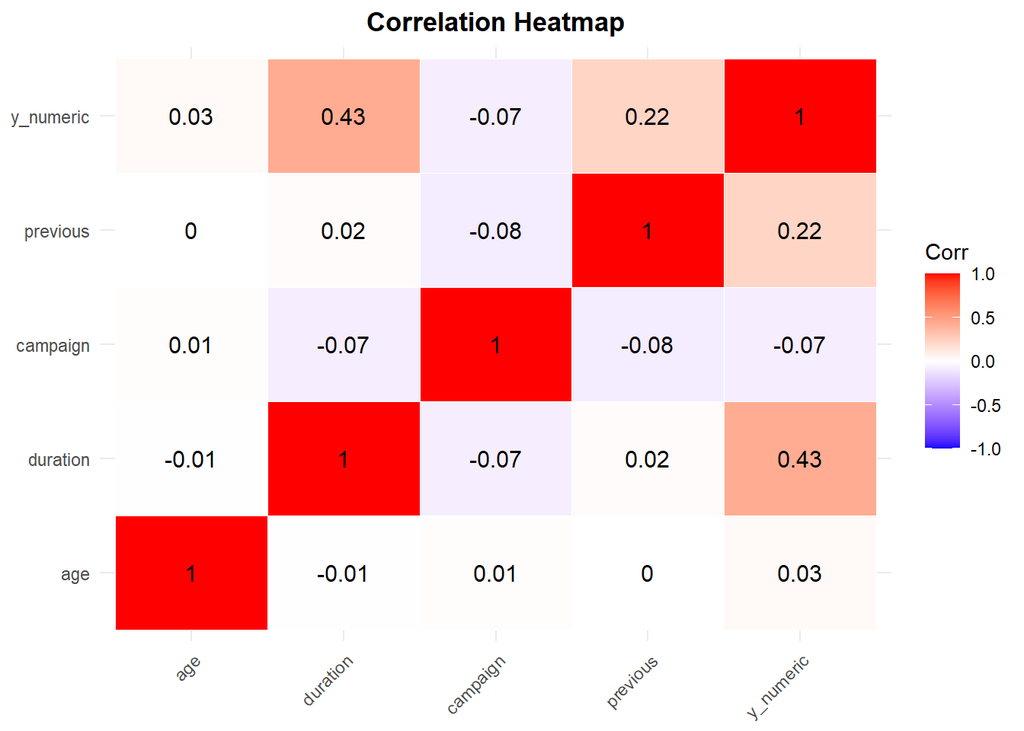

`"Duration"` has a **positive correlation (0.43)** with y_numeric, which represents whether a client says yes. This means that **longer conversations are more likely to lead to a positive response** from the client. So, as the duration increases, the chance that the client agrees also increases.

#### Cross Tabulation Job & Campagin Result

| job | no | yes |
| --- | --- | --- |
| blue-collar | 2676 (92.9%) | 204 (7.1%) |
| non-working | 421 (77.5%) | 122 (22.5%) |
| self-employed | 525 (91.8%) | 47 (8.2%) |
| student | 133 (73.5%) | 48 (26.5%) |
| white-collar | 3547 (87.4%) | 513 (12.6%) |

The client’s profession appears to affect the decision. For example, **students** say “yes” the most **(26.5%)**, while **blue-collar workers** say “yes” the least **(7.1%)**. This suggests that a **client’s job may influence how likely they are to accept the offer.**

#### Previos Outcome And Campagin Result(y)

| poutcome | no | yes |
| --- | --- | --- |
| failure | 740 (84.5%) | 136 (15.5%) |
| nonexistent | 6456 (91.1%) | 630 (8.9%) |
| success | 106 (38.7%) | 168 (61.3%) |

There is a clear relationship between **previous outcomes** and campaign successness. When the previous outcome was **success**, **61.3%** of clients said “yes”. But if it was **failure**, only **15.5%** said “yes”, and if it was **nonexistent**, just **8.9%**.

### 2b. Feature Engineering

These are the summary of the new variable, that have been created from another variable:

```
##
## === New Variable Summary ===
##  age_group    recency_level total_contact_score
##  <30  :1135   never :7932   Min.   : 1.000
##  30–50:5671   old   :  71   1st Qu.: 1.000
##  >50  :1430   recent: 233   Median : 2.000
##                             Mean   : 2.585
##                             3rd Qu.: 3.000
##                             Max.   :11.000
```

### 2c. Interactive Visualizations

We have made three interactive chart using Plotly, there are:

**1. Chart of Previous Outcome & Campaign Result**  
Clients are much more likely to respond positively if the previous campaign was successful. The chart shows that over 60% of clients said “yes” after a prior success, compared to only around 10–15% for failure or no previous contact. This highlights the strong influence of past campaign outcomes on current conversions.

[interactive chart not shown]

**2. Chart of Duration & Campaign Result**

Clients who say “yes” tend to have much longer conversations, with an average duration of **512 seconds**, compared to only **219 seconds** for those who say “no”. This suggests that **longer calls significantly increase the chance of a successful campaign outcome.**

[interactive chart not shown]

**3. Chart of Recency Level, Age Group & Campaign Result**

There is a clear **U-shaped pattern**, where **clients under 30 and over 50 consistently have higher success rates than those aged 30–50.** Additionally, previous contact matters a lot, **contacts lead to much higher success rates across all age groups.** This suggests that **both age and contact strongly impact campaign effectiveness.**

[interactive chart not shown]

## 3. Insight Storytelling & Recommendations

### 3a. Data Storytelling Through Visuals Designs

#### First Key Finding: Clients with Prior Success and Specific Age Groups Drive the Highest Conversions

[interactive chart not shown]

#### Second Key Finding: Longer Call Durations Lead to Significantly Higher Conversion

[interactive chart not shown]

### 3c. Make Business Recommendation

Based on the data and visualization insight, I will give two specific recommendation:

- **Prioritize targeting clients who previously responded positively to campaigns**, especially those **under 30 or over 50 years old.** These clients have a conversion rate of 67% - 72%, and the age segments show a U-shaped pattern, where <30 and >50 consistently outperform the 30–50 age group. Focus marketing budget and personalization strategies on these segments, build a high potential leads list based on age and past response for future campaigns.
- **Encourage call agents to extend conversations beyond 5 minutes whenever possible.** Clients who spoke for more than 5 minutes converted at 29.4%, nearly 3× higher than those in the 3–5 minute range. It is recommended to set call duration KPIs and give bonuses for longer, high-quality calls, also adjust scripts to support deeper conversations, and promote longer.